# Lecture 5: Supervised Methods

Yanfei Kang  
yanfeikang@buaa.edu.cn

School of Economics and Management  
Beihang University

# Packages required in this lecture

- `caret` and its dependences

# Unsupervised methods

#### Clustering: working without known targets

- Suppose you want to segment your customers into general categories of people with similar buying patterns.
- You might not know in advance what these groups should be.

# Supervised methods

#### Classification: deciding how to assign (known) labels to an object.

- Supervised learning
- To learn how to classify objects, you need a dataset of objects that have already been classified (training set)

# Examples of classification problems

- Identifying spam email
- Sorting products in a product catalog
- Identifying loans that are about to default
- Assigning customers to customer clusters

# Some common classification methods

#### Logistic regression

- Logistic regression is appropriate when you want to estimate class probabilities (the probability that an object is in a given class).
- An example use of a logistic regression–based classifier is estimating the probability of fraud in credit card purchases.
- Logistic regression is also a good choice when you want an idea of the relative impact of different input variables on the output. For example, you might find out that a $100 increase in transaction size increases the odds that the transaction is fraud by 2%, all else being equal.

# Some common classification methods

#### K nearest neighbours (KNN)

- In k-NN classification, the output is a class membership. An object is classified by a majority vote of its neighbors, with the object being assigned to the class most common among its k nearest neighbors (k is a positive integer, typically small).
- If k = 1, then the object is simply assigned to the class of that single nearest neighbor.

# Some common classification methods

#### Naive Bayes

Naive Bayes classifiers are especially useful for problems with many input variables, categorical input variables with a very large number of possible values, and text classification.

# Some common classification methods

#### Decision trees

- Decision trees are useful when input variables interact with the output in “if-then”" kinds of ways (such as IF age > 65, THEN has.health.insurance=T).
- They are also suitable when inputs have an AND relationship to each other (such as IF age < 25 AND student=T, THEN…) or when input variables are redundant or correlated.
- The decision rules that come from a decision tree are in principle easier for nontechnical users to understand than the decision processes that come from other classifiers.
- Random forests are important extensions of decision trees.

# Some common classification methods

#### Support vector machines

- Support vector machines (SVMs) are useful when there are very many input variables or when input variables interact with the outcome or with each other in complicated (nonlinear) ways.
- SVMs make fewer assumptions about variable distribution than do many other methods, which makes them especially useful when the training data isn’t completely representative of the way the data is distributed in production.

# Case study: [Titanic disaster](https://www.kaggle.com/c/titanic/)

- The sinking of the Titanic is one of the most infamous shipwrecks in history. One of the reasons that the shipwreck led to such loss of life was that there were not enough lifeboats for the passengers and crew.
- Although there was some element of luck involved in surviving the sinking, some groups of people were more likely to survive than others, such as women, children, and the upper-class.

# Our data

Each record in the dataset describes a passenger. The attributes are defined as follows:

1. PassengerId: Unique passenger identification number
2. Survived: Did a passenger survive or not (0 = died, 1 = survived)
3. Pclass: Passenger Class (1 = 1st; 2 = 2nd; 3 = 3rd)
4. Name: Name of Passenger
5. Sex: Sex of Passenger
6. Age: Passenger Age
7. SibSp: Number of Siblings/Spouses Aboard
8. Parch: Number of Parents/Children Aboard
9. Ticket: Ticket Number
10. Fare: Passenger Fare
11. Cabin: Cabin
12. Embarked: Port of Embarkation (C = Cherbourg; Q = Queenstown; S = Southampton)

# Data preparation

```r
library(caret)
# load the CSV file from the local directory
datasetTrain <- read.csv("https://yanfei.site/docs/dpsa/train.csv", header=TRUE, sep = ",")
datasetTest <- read.csv("https://yanfei.site/docs/dpsa/test.csv", header=TRUE, sep = ",")
```

Our problem to solve is to predict the survival of the passengers in the test dataset.

# Data summarization

```r
# dimension
dim(datasetTrain)
```

```
## [1] 891  12
```

```r
# attribute class type
sapply(datasetTrain, class)
```

```
##        ID  Survived    Pclass      Name       Sex       Age     SibSp
## "integer" "integer" "integer"  "factor"  "factor" "numeric" "integer"
##     Parch    Ticket      Fare     Cabin  Embarked
## "integer"  "factor" "numeric"  "factor"  "factor"
```

```r
head(datasetTrain)
```

```
##   ID Survived Pclass                                                Name
## 1  1        0      3                             Braund, Mr. Owen Harris
## 2  2        1      1 Cumings, Mrs. John Bradley (Florence Briggs Thayer)
## 3  3        1      3                              Heikkinen, Miss. Laina
## 4  4        1      1        Futrelle, Mrs. Jacques Heath (Lily May Peel)
## 5  5        0      3                            Allen, Mr. William Henry
## 6  6        0      3                                    Moran, Mr. James
##      Sex Age SibSp Parch           Ticket    Fare Cabin Embarked
## 1   male  22     1     0        A/5 21171  7.2500              S
## 2 female  38     1     0         PC 17599 71.2833   C85        C
## 3 female  26     0     0 STON/O2. 3101282  7.9250              S
## 4 female  35     1     0           113803 53.1000  C123        S
## 5   male  35     0     0           373450  8.0500              S
## 6   male  NA     0     0           330877  8.4583              Q
```

```r
# remove redundant variables
datasetTrain <- datasetTrain[, c(-1, -4, -9, -11, -12)]

# summary
summary(datasetTrain)
```

```
##     Survived          Pclass          Sex           Age
##  Min.   :0.0000   Min.   :1.000   female:314   Min.   : 0.42
##  1st Qu.:0.0000   1st Qu.:2.000   male  :577   1st Qu.:20.12
##  Median :0.0000   Median :3.000                Median :28.00
##  Mean   :0.3838   Mean   :2.309                Mean   :29.70
##  3rd Qu.:1.0000   3rd Qu.:3.000                3rd Qu.:38.00
##  Max.   :1.0000   Max.   :3.000                Max.   :80.00
##                                                NA's   :177
##      SibSp           Parch             Fare
##  Min.   :0.000   Min.   :0.0000   Min.   :  0.00
##  1st Qu.:0.000   1st Qu.:0.0000   1st Qu.:  7.91
##  Median :0.000   Median :0.0000   Median : 14.45
##  Mean   :0.523   Mean   :0.3816   Mean   : 32.20
##  3rd Qu.:1.000   3rd Qu.:0.0000   3rd Qu.: 31.00
##  Max.   :8.000   Max.   :6.0000   Max.   :512.33
##
```

```r
# Percentage of survived
table(datasetTrain$Survived)
```

```
##
##   0   1
## 549 342
```

```r
prop.table(table(datasetTrain$Survived))
```

```
##
##         0         1
## 0.6161616 0.3838384
```

```r
# convert survived to factor
datasetTrain[,1] <- as.factor((datasetTrain[,1]))
data <- datasetTrain
data[,3] <- as.numeric((data[,3]))
complete_cases <- complete.cases(data)
```

# Data visualization

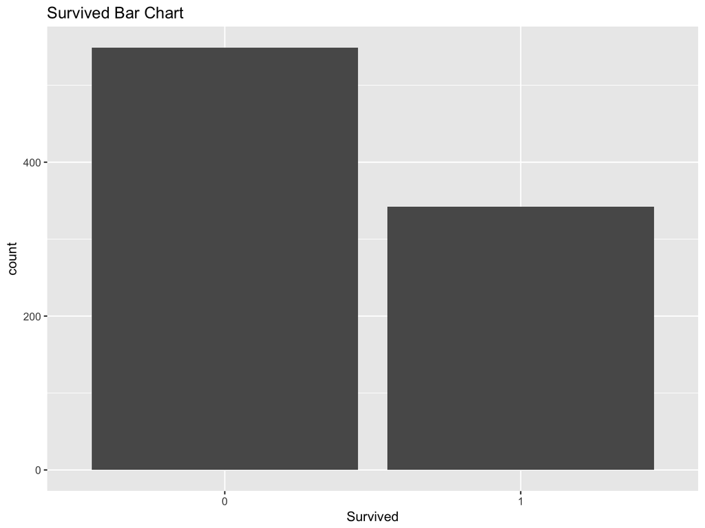

```r
# survival bar chart
ggplot(datasetTrain, aes(x = Survived)) + geom_bar() + ggtitle("Survived Bar Chart")
```

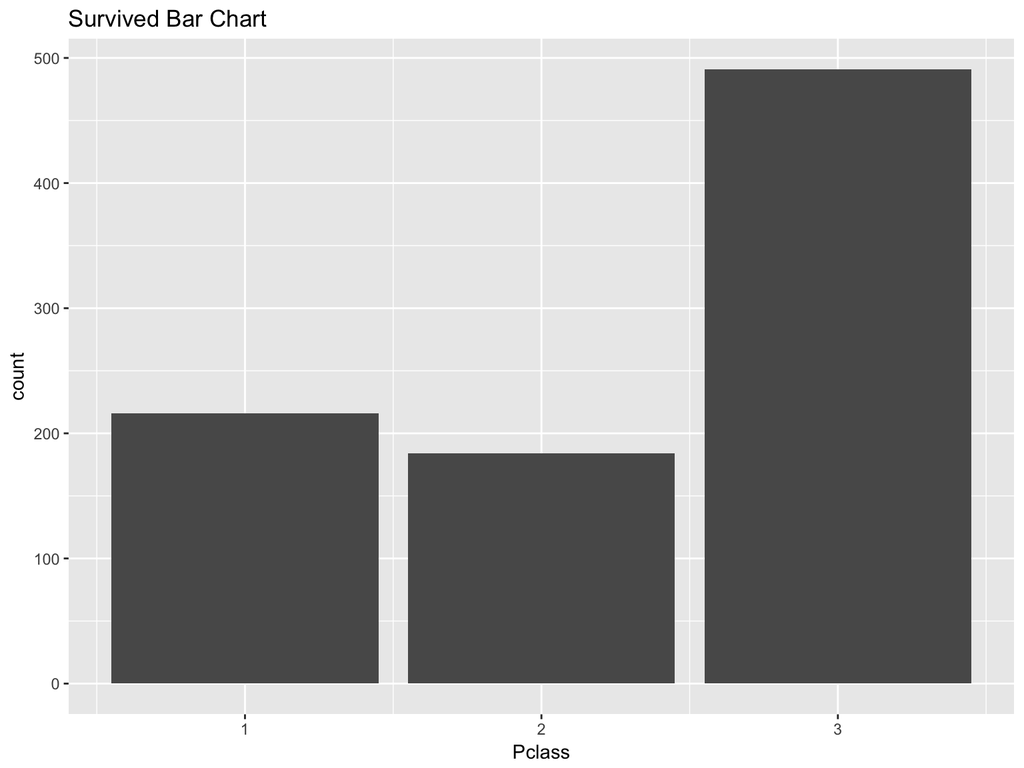

```r
# Pclass distribution
ggplot(datasetTrain, aes(x = Pclass)) + geom_bar() + ggtitle("Survived Bar Chart")
```

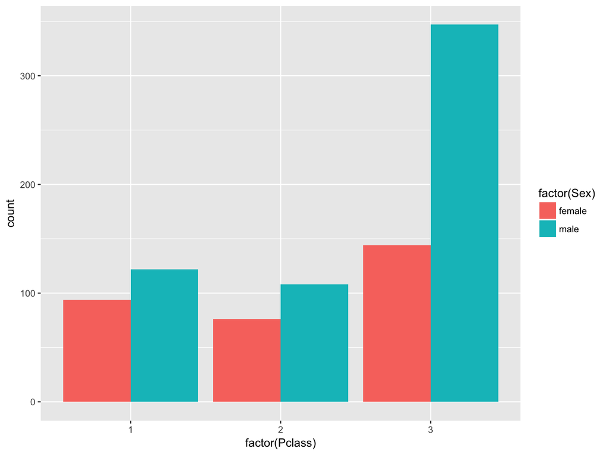

```r
# barplot of males and females in each class
ggplot(datasetTrain, aes(x = factor(Pclass), fill = factor(Sex))) +
geom_bar(position = "dodge")
```

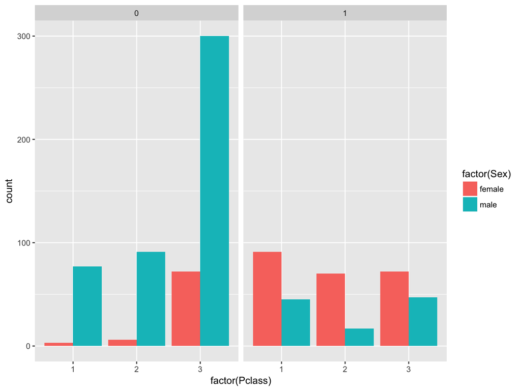

```r
# barplot of males and females who survived in each class
ggplot(datasetTrain, aes(x = factor(Pclass), fill = factor(Sex))) +
geom_bar(position = "dodge") +
facet_grid(". ~ Survived")
```

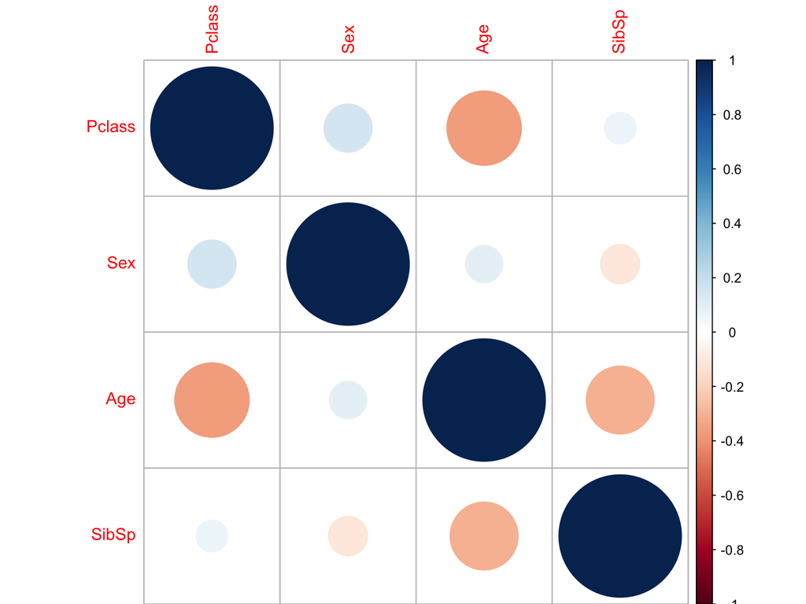

```r
library(corrplot)
corrplot(cor(data[complete_cases, 2:5]))
```

# Build models

```r
# Model evaluation methods
# 10-fold cross validation with 3 repeats
trainControl <-
  trainControl(method = "repeatedcv",
               number = 10,
               repeats = 3)
metric <- "Accuracy"

# logistic regression
fit.glm <- train(Survived~.,
                 data=datasetTrain,
                 method="glm",
                 metric=metric,
                 na.action = na.exclude,
                 trControl=trainControl)

# KNN
fit.knn <- train(Survived~.,
                 data=datasetTrain,
                 method="knn",
                 metric=metric,
                 na.action = na.exclude,
                 trControl=trainControl)

# Naive Bayes
fit.nb <- train(Survived~.,
                data=datasetTrain,
                method="nb",
                metric=metric,
                na.action = na.exclude,
                trControl=trainControl)

# Decision tree
fit.cart <- train(Survived~.,
                  data=datasetTrain,
                  method="rpart",
                  metric=metric,
                  na.action = na.exclude,
                  trControl=trainControl)

# SVM
fit.svm <- train(Survived~.,
                 data=datasetTrain,
                 method="svmRadial",
                 metric=metric,
                 na.action = na.exclude,
                 trControl=trainControl)
```

#### Cross validation

- The samples are randomly partitioned into k sets of roughly equal size. A model is fit using the all samples except the first subset (called the first fold). The held-out samples are predicted by this model and used to estimate performance measures.
- The first subset is returned to the training set and procedure repeats with the second subset held out, and so on.
- The k resampled estimates of performance are summarized and used to understand the relationship between the tuning parameter(s) and model utility.

# Algorithm comparison

```r
# Compare algorithms
results <- resamples(list(LG=fit.glm,
                          KNN=fit.knn,
                          CART=fit.cart,
                          NB=fit.nb,
                          SVM=fit.svm))
summary(results)
```

```
##
## Call:
## summary.resamples(object = results)
##
## Models: LG, KNN, CART, NB, SVM
## Number of resamples: 30
##
## Accuracy
##        Min. 1st Qu. Median   Mean 3rd Qu.   Max. NA's
## LG   0.6806  0.7666 0.8028 0.8002  0.8415 0.9028    0
## KNN  0.6056  0.6620 0.7042 0.6975  0.7222 0.7887    0
## CART 0.7042  0.7474 0.7762 0.7801  0.8056 0.8873    0
## NB   0.6806  0.7526 0.7887 0.7811  0.8141 0.8732    0
## SVM  0.7222  0.8056 0.8310 0.8269  0.8451 0.9028    0
##
## Kappa
##        Min. 1st Qu. Median   Mean 3rd Qu.   Max. NA's
## LG   0.3323  0.5107 0.5893 0.5817  0.6673 0.7968    0
## KNN  0.1569  0.2929 0.3846 0.3621  0.4151 0.5557    0
## CART 0.3551  0.4558 0.5106 0.5245  0.5819 0.7668    0
## NB   0.3168  0.4861 0.5508 0.5422  0.6138 0.7275    0
## SVM  0.4161  0.5839 0.6399 0.6305  0.6750 0.7921    0
```

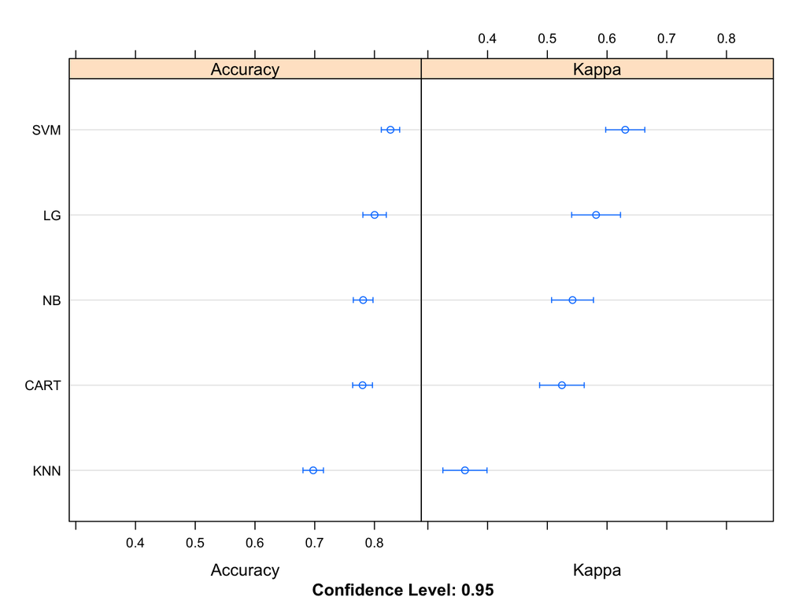

```r
dotplot(results)
```

# Finalize model

```r
model <- train(Survived~.,
               data=datasetTrain,
               method="svmRadial",
               metric=metric,
               na.action = na.exclude,
               trControl=trainControl)
testData <- datasetTest[,c(-1, -8, -10, -11)]
testData$Age[is.na(testData$Age)] <- 0
testData$Fare[is.na(testData$Fare)] <- 0
predictions <- predict(model, testData)
```

# References

1. Nina Zumel and John Mount (2014). Data Science with R. Manning.
2. The [caret](https://topepo.github.io/caret/index.html) package in **R**.